# Assignment2

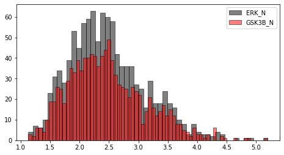

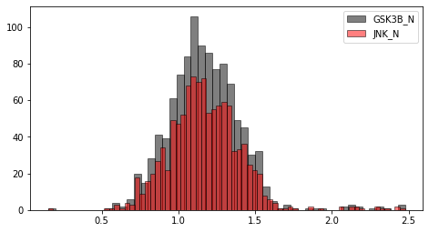

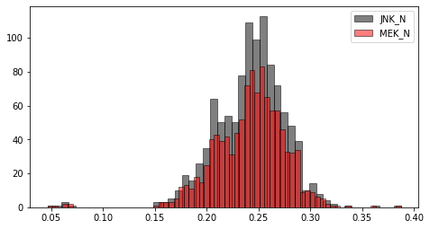

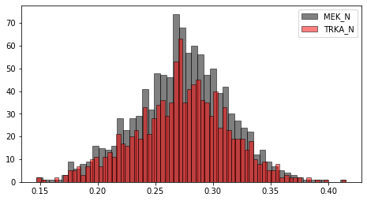

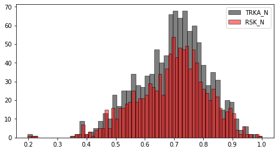

```python
#plotting the distribution of a few different proteins together
k=1
j=0
list = ['ERK_N', 'GSK3B_N', 'JNK_N', 'MEK_N', 'TRKA_N','RSK_N']
for i in update_mice_protein_data.columns[25:30]:
    fig2 = plt.figure(figsize=(17, 14))
    plt.subplot(3,2,k)
    plt.hist(update_mice_protein_data[list[j]], bins=50, alpha=0.5, label=list[j], edgecolor= "black", color = "black")
    plt.hist(update_mice_protein_data[list[j]], bins=70, alpha=0.5, label=list[j+1],edgecolor= "black", color = "red")
    plt.legend(loc='upper right')
    plt.show()
    k+=1
    j+=1
```

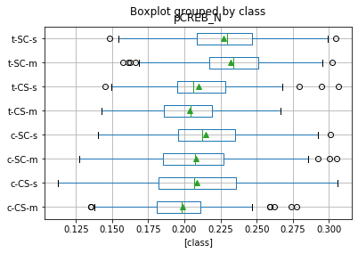

```python
update_mice_protein_data.boxplot(column=['pCREB_N'],vert=0,showmeans=True,by=['class'])
```

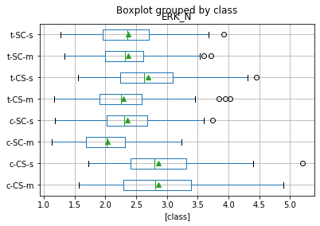

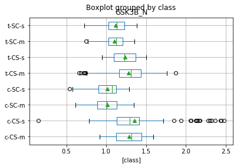

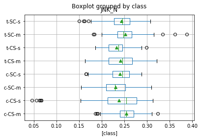

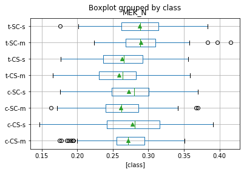

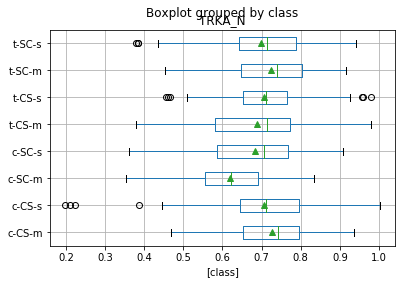

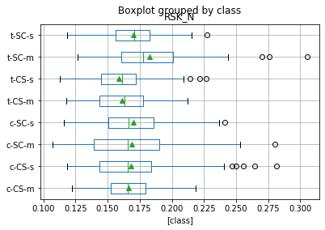

```python
list = ['ERK_N', 'GSK3B_N', 'JNK_N', 'MEK_N', 'TRKA_N', 'RSK_N']
j=0
while j<6:
    update_mice_protein_data.boxplot(column=[list[j]],vert=0,showmeans=True,by=['class'])
    j=j+1
```

[output not shown]

[output cut: 88 more lines]

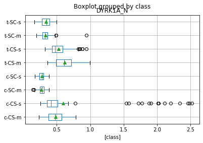

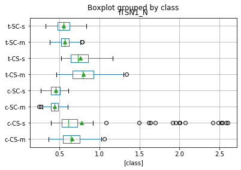

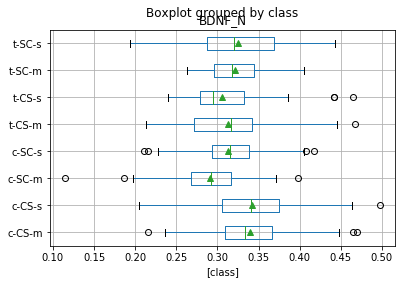

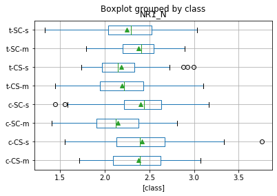

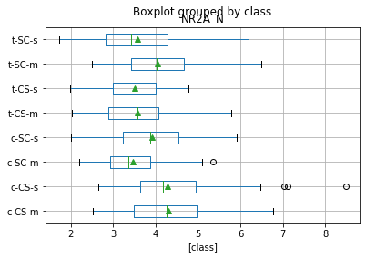

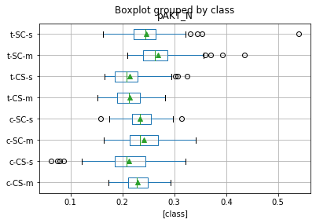

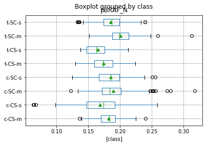

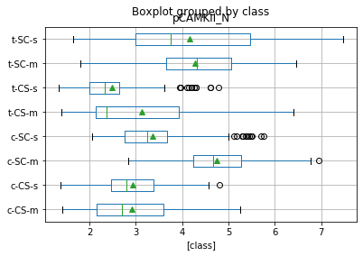

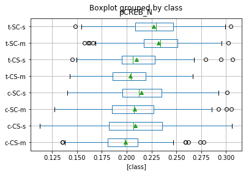

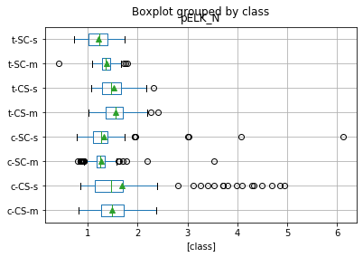

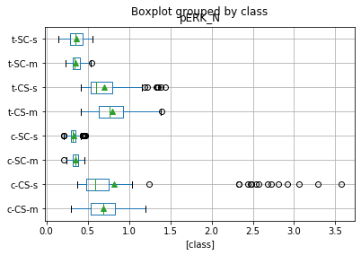

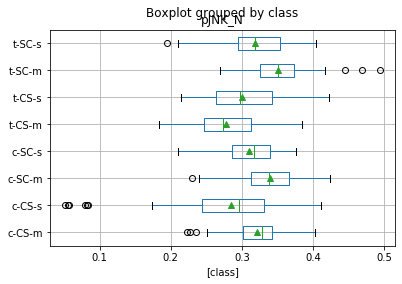

[65 more figures not shown]

```python
list = ['DYRK1A_N', 'ITSN1_N', 'BDNF_N', 'NR1_N', 'NR2A_N', 'pAKT_N', 'pBRAF_N',
       'pCAMKII_N', 'pCREB_N', 'pELK_N', 'pERK_N', 'pJNK_N', 'PKCA_N',
       'pMEK_N', 'pNR1_N', 'pNR2A_N', 'pNR2B_N', 'pPKCAB_N', 'pRSK_N', 'AKT_N',
       'BRAF_N', 'CAMKII_N', 'CREB_N', 'ELK_N', 'ERK_N', 'GSK3B_N', 'JNK_N',
       'MEK_N', 'TRKA_N', 'RSK_N', 'APP_N', 'Bcatenin_N', 'SOD1_N', 'MTOR_N',
       'P38_N', 'pMTOR_N', 'DSCR1_N', 'AMPKA_N', 'NR2B_N', 'pNUMB_N',
       'RAPTOR_N', 'TIAM1_N', 'pP70S6_N', 'NUMB_N', 'P70S6_N', 'pGSK3B_N',
       'pPKCG_N', 'CDK5_N', 'S6_N', 'ADARB1_N', 'AcetylH3K9_N', 'RRP1_N',
       'BAX_N', 'ARC_N', 'ERBB4_N', 'nNOS_N', 'Tau_N', 'GFAP_N', 'GluR3_N',
       'GluR4_N', 'IL1B_N', 'P3525_N', 'pCASP9_N', 'PSD95_N', 'SNCA_N',
       'Ubiquitin_N', 'pGSK3B_Tyr216_N', 'SHH_N', 'BAD_N', 'BCL2_N', 'pS6_N',
       'pCFOS_N', 'SYP_N', 'H3AcK18_N', 'EGR1_N', 'H3MeK4_N', 'CaNA_N']
j=0

while j<77:
    update_mice_protein_data.boxplot(column=[list[j]],vert=0,showmeans=True,by=['class'])
    j=j+1
```

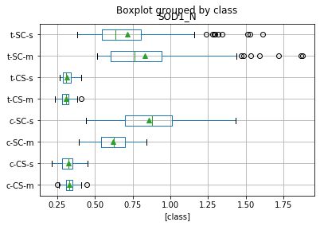

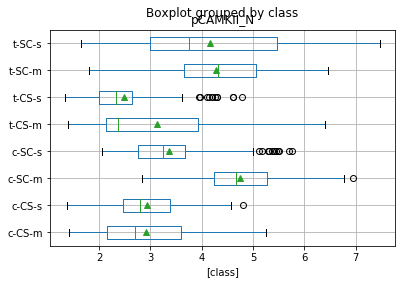

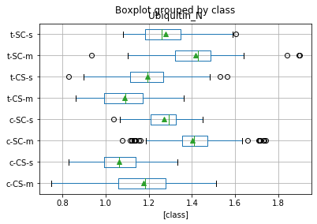

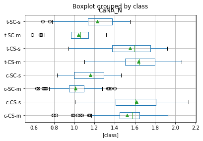

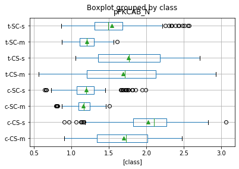

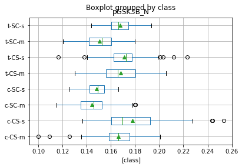

```python
list = ['SOD1_N', 'pCAMKII_N', 'Ubiquitin_N', 'CaNA_N', 'pPKCAB_N', 'pGSK3B_N']
j=0
while j<6:
    update_mice_protein_data.boxplot(column=[list[j]],vert=0,showmeans=True,by=['class'])
    j=j+1
```

DATA MODELLING

Making a random forest classifier with target variable 'class'

```python
#Training
X = update_mice_protein_data.loc[:, 'DYRK1A_N':'CaNA_N']
y = update_mice_protein_data['class']
```

```python
from sklearn.model_selection import train_test_split
X_train, X_test, y_train, y_test = train_test_split(X,y,test_size=0.4,random_state=1)

from sklearn.ensemble import RandomForestClassifier
random_forest_clf = RandomForestClassifier(max_depth=12,n_estimators=1000, random_state=1, n_jobs=1)
random_forest_clf_fitted = random_forest_clf.fit(X_train, y_train)

from sklearn.metrics import confusion_matrix, accuracy_score
y_predict = random_forest_clf.predict(X_test)
accuracy_score(y_test,y_predict)
```

```
0.9884259259259259
```

```python
#getting the hyper parameters used by classifier after tuning
print(random_forest_clf.get_params())
```

```
{'bootstrap': True, 'class_weight': None, 'criterion': 'gini', 'max_depth': 12, 'max_features': 'auto', 'max_leaf_nodes': None, 'min_impurity_decrease': 0.0, 'min_impurity_split': None, 'min_samples_leaf': 1, 'min_samples_split': 2, 'min_weight_fraction_leaf': 0.0, 'n_estimators': 1000, 'n_jobs': 1,…
```

```python
#getting all the important values to series
imp_values = pd.Series(random_forest_clf.feature_importances_,index=X.columns)
```

```python
list = ['DYRK1A_N', 'ITSN1_N', 'BDNF_N', 'NR1_N', 'NR2A_N', 'pAKT_N', 'pBRAF_N',
       'pCAMKII_N', 'pCREB_N', 'pELK_N', 'pERK_N', 'pJNK_N', 'PKCA_N',
       'pMEK_N', 'pNR1_N', 'pNR2A_N', 'pNR2B_N', 'pPKCAB_N', 'pRSK_N', 'AKT_N',
       'BRAF_N', 'CAMKII_N', 'CREB_N', 'ELK_N', 'ERK_N', 'GSK3B_N', 'JNK_N',
       'MEK_N', 'TRKA_N', 'RSK_N', 'APP_N', 'Bcatenin_N', 'SOD1_N', 'MTOR_N',
       'P38_N', 'pMTOR_N', 'DSCR1_N', 'AMPKA_N', 'NR2B_N', 'pNUMB_N',
       'RAPTOR_N', 'TIAM1_N', 'pP70S6_N', 'NUMB_N', 'P70S6_N', 'pGSK3B_N',
       'pPKCG_N', 'CDK5_N', 'S6_N', 'ADARB1_N', 'AcetylH3K9_N', 'RRP1_N',
       'BAX_N', 'ARC_N', 'ERBB4_N', 'nNOS_N', 'Tau_N', 'GFAP_N', 'GluR3_N',
       'GluR4_N', 'IL1B_N', 'P3525_N', 'pCASP9_N', 'PSD95_N', 'SNCA_N',
       'Ubiquitin_N', 'pGSK3B_Tyr216_N', 'SHH_N', 'BAD_N', 'BCL2_N', 'pS6_N',
       'pCFOS_N', 'SYP_N', 'H3AcK18_N', 'EGR1_N', 'H3MeK4_N', 'CaNA_N']
df = pd.DataFrame(random_forest_clf.feature_importances_,update_mice_protein_data.columns[1:78],columns=['Values'])
print(df)
```

```
             Values
DYRK1A_N   0.027272
ITSN1_N    0.024591
BDNF_N     0.006074
NR1_N      0.006556
NR2A_N     0.005426
...             ...
SYP_N      0.007322
H3AcK18_N  0.011838
EGR1_N     0.004624
H3MeK4_N   0.005972
CaNA_N     0.032884

[77 rows x 1 columns]
```

```python
df_importance = df[df['Values']>0.0155]
```

```python
df_importance.sort_values('Values', ascending=False, inplace=True)
print(df_importance)
```

```
                Values
SOD1_N        0.058909
pPKCG_N       0.037580
pERK_N        0.035993
APP_N         0.033460
CaNA_N        0.032884
Ubiquitin_N   0.030103
DYRK1A_N      0.027272
pCAMKII_N     0.026176
ITSN1_N       0.024591
pPKCAB_N      0.023523
P38_N         0.023488
ARC_N         0.023314
pS6_N         0.022822
Tau_N         0.022453
BRAF_N        0.021110
pNUMB_N       0.020465
pP70S6_N      0.020057
S6_N          0.018893
pGSK3B_N      0.017598
AKT_N         0.017350
AcetylH3K9_N  0.017090
```

```python
#I will use a threshold to get the most important attributes(a.k.a proteins here)

#It will be done by creating a selector objcet that will use random forest classifier
#choosing a particular importance
from sklearn.feature_selection import SelectFromModel

selector = SelectFromModel(random_forest_clf,threshold=0.0155)

#Train
selector.fit(X_train,y_train)
```

```
SelectFromModel(estimator=RandomForestClassifier(bootstrap=True,
                                                 class_weight=None,
                                                 criterion='gini', max_depth=12,
                                                 max_features='auto',
                                                 max_leaf_nodes=None,
                                                 min_impurity_decrease=0.0,
                                                 min_impurity_split=None,
                                                 min_samples_leaf=1,
                                                 min_samples_split=2,
                                                 min_weight_fraction_leaf=0.0,
                                                 n_estimators=1000, n_jobs=1,
                                                 oob_score=False,
                                                 random_state=1, verbose=0,
                                                 warm_start=False),
                max_features=None, norm_order=1, prefit=False,
                threshold=0.0155)
```

```python
#creating new data set from the sfm model to test the accuracy with most imp features
X_imp_train = selector.transform(X_train)
X_imp_test = selector.transform(X_test)
#creating a new classifier with most imp features
random_forest_clf_imp = RandomForestClassifier(max_depth=15,n_estimators=100, random_state=1, n_jobs=1)
#training the classifier with most imp features
random_forest_clf_imp.fit(X_imp_train,y_train)
#predicting the values with important features clf
y_imp_predict = random_forest_clf_imp.predict(X_imp_test)
#accuracy score
from sklearn.metrics import confusion_matrix, accuracy_score
accuracy_score(y_test,y_imp_predict)
```

```
0.9907407407407407
```

With a threshold of 0.010, the accuracy is decreased a bit -> accuracy = 0.9652 With a threshold of 0.020, the accuracy is decreased a bit -> accuracy = 0.9560 With a threshold of 0.015(mean of the two), the accuracy is -> 0.990740 (better than before) Now testing for threshold of 0.016(might increase/decrease/constant) -> 0.990740 Now testing for threshold of 0.014(might increase/decrease/constant) -> 0.990740 Now testing for threshold of 0.017(might increase/decrease/constant) -> 0.990740 Now testing for threshold of 0.013 -> 0.96990740 As the value remains constant when 0.014<threshold<0.017, i will be taking the average value amongst it So, threshold = 0.0155

```python
# from sklearn.ensemble import RandomForestRegressor
# from sklearn.model_selection import GridSearchCV
# #param_grid = {'max_depth': [12]}
# param_grid = {'bootstrap': [True, False],
#  'max_depth': [10,12,14,21, None],
#  'max_features': ['auto', 'sqrt'],
#  'min_samples_leaf': [1, 2, 4],
#  'min_samples_split': [2, 5, 10],
#  'n_estimators': [1000,2000]}
# ref = RandomForestRegressor()
# grid_search = GridSearchCV(random_forest_clf, param_grid = param_grid, cv=3, n_jobs=-1, verbose = 2)
# grid_search.fit(X_imp_train,y_train)

# grid_search.best_params_

# #rained the model using the above Grid Search Algorithm which took me around 9 hourse to train one model, i.e, 2*12*2*3*3*10 which is 4320 combinations and with cv = 3, there would be 12960 different parameter combination
# #Ran this for once and got a value for max depth to be 12 which gives me the highest accuracy
```

```python
#print(grid_search.best_params_)
# {'bootstrap': False,
#  'max_depth': 12,
#  'max_features': 'auto',
#  'min_samples_leaf': 1,
#  'min_samples_split': 2,
#  'n_estimators': 1000}
```

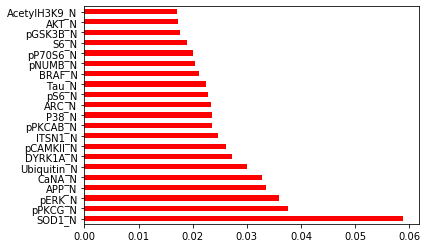

```python
imp_values.nlargest(21).plot(kind='barh',color="red")
plt.show()
```

Making a random forest classifier with target variable 'Genotype'

```python
#making the model for GenoType
```

```python
X = update_mice_protein_data.loc[:, 'DYRK1A_N':'CaNA_N']
y_geno = update_mice_protein_data['Genotype']

from sklearn.model_selection import train_test_split
X_train, X_test, y_geno_train, y_geno_test = train_test_split(X,y_geno,test_size=0.4,random_state=1)

from sklearn.ensemble import RandomForestClassifier
random_forest_clf = RandomForestClassifier(max_depth=12,n_estimators=100, random_state=1, n_jobs=1)

random_forest_clf_fitted = random_forest_clf.fit(X_train, y_geno_train)

from sklearn.metrics import confusion_matrix, accuracy_score
y_geno_predict = random_forest_clf.predict(X_test)
accuracy_score(y_geno_test,y_geno_predict)
#with max_depth 0f 12, i get the most accuracy which is otherwish 0.98148 for values like max_depth = 13,11,14 or defualt
```

```
0.9861111111111112
```

```python
#I will use a threshold to get the most important attributes(a.k.a proteins here)

#It will be done by creating a selector objcet that will use random forest classifier
#choosing a particular importance
from sklearn.feature_selection import SelectFromModel

selector = SelectFromModel(random_forest_clf,threshold=0.003)

#Train
selector.fit(X_train,y_geno_train)

#Storing the most imp proteins in arrays
```

```
SelectFromModel(estimator=RandomForestClassifier(bootstrap=True,
                                                 class_weight=None,
                                                 criterion='gini', max_depth=12,
                                                 max_features='auto',
                                                 max_leaf_nodes=None,
                                                 min_impurity_decrease=0.0,
                                                 min_impurity_split=None,
                                                 min_samples_leaf=1,
                                                 min_samples_split=2,
                                                 min_weight_fraction_leaf=0.0,
                                                 n_estimators=100, n_jobs=1,
                                                 oob_score=False,
                                                 random_state=1, verbose=0,
                                                 warm_start=False),
                max_features=None, norm_order=1, prefit=False, threshold=0.003)
```

```python
df_imp = df[df["Values"]>0.003]
df_imp.shape
```

```
(77, 1)
```

```python
df_imp.sort_values("Values",ascending=True)
```

|  | Values |
| --- | --- |
| pCFOS_N | 0.004058 |
| EGR1_N | 0.004624 |
| MEK_N | 0.004633 |
| Bcatenin_N | 0.004860 |
| pNR2B_N | 0.004886 |
| ... | ... |
| CaNA_N | 0.032884 |
| APP_N | 0.033460 |
| pERK_N | 0.035993 |
| pPKCG_N | 0.037580 |
| SOD1_N | 0.058909 |

77 rows × 1 columns

```python
#creating new data set from the sfm model to test the accuracy with most imp features
X_imp_train = selector.transform(X_train)
X_imp_test = selector.transform(X_test)
#creating a new classifier with most imp features
random_forest_clf_imp = RandomForestClassifier(max_depth=12,n_estimators=100, random_state=1, n_jobs=1)
#training the classifier with most imp features
random_forest_clf_imp.fit(X_imp_train,y_geno_train)
#predicting the values with important features clf
y_geno_imp_predict = random_forest_clf_imp.predict(X_imp_test)
#accuracy score
from sklearn.metrics import confusion_matrix, accuracy_score
accuracy_score(y_geno_test,y_geno_imp_predict)
```

```
0.9861111111111112
```

```python
#The accuracy value remain same for "Genotype" even after selecting the most imporatant which are atleast 77(basically all the attributes)
#even after building the model over all the attributes the accuracy remains 0.9861111
#Hence we require all the attributes to train our model to achieve max accuracy
```

Making a random forest classifier with target variable 'Treatment'

```python
#Building a model for Treatment
```

```python
X = update_mice_protein_data.loc[:, 'DYRK1A_N':'CaNA_N']
y_treat = update_mice_protein_data['Treatment']

from sklearn.model_selection import train_test_split
X_train, X_test, y_treat_train, y_treat_test = train_test_split(X,y_treat,test_size=0.4,random_state=1)

from sklearn.ensemble import RandomForestClassifier
random_forest_clf = RandomForestClassifier(max_depth=9,n_estimators=100, random_state=1, n_jobs=1)

random_forest_clf_fitted = random_forest_clf.fit(X_train, y_treat_train)

from sklearn.metrics import confusion_matrix, accuracy_score
y_treat_predict = random_forest_clf.predict(X_test)
accuracy_score(y_treat_test,y_treat_predict)
#with max_depth of 9 and above, the accuracy is most which is 0.988425, using default value gives the same accuracy
```

```
0.9884259259259259
```

```python
#I will use a threshold to get the most important attributes(a.k.a proteins here)

#It will be done by creating a selector objcet that will use random forest classifier
#choosing a particular importance
from sklearn.feature_selection import SelectFromModel

selector = SelectFromModel(random_forest_clf,threshold=0.003)

#Train
selector.fit(X_train,y_treat_train)

#Storing the most imp proteins in arrays
```

```
SelectFromModel(estimator=RandomForestClassifier(bootstrap=True,
                                                 class_weight=None,
                                                 criterion='gini', max_depth=9,
                                                 max_features='auto',
                                                 max_leaf_nodes=None,
                                                 min_impurity_decrease=0.0,
                                                 min_impurity_split=None,
                                                 min_samples_leaf=1,
                                                 min_samples_split=2,
                                                 min_weight_fraction_leaf=0.0,
                                                 n_estimators=100, n_jobs=1,
                                                 oob_score=False,
                                                 random_state=1, verbose=0,
                                                 warm_start=False),
                max_features=None, norm_order=1, prefit=False, threshold=0.003)
```